# Creating Figure 4

# Preamble

*This will be a general preamble common to several documents included as Electronic Supplements to CARMMHA’s BB BND injury paper. The exact preamble will be finalized at the time of submission to reflect the submission date and final title, structure, authors etc.*

The master file with supplementary material is here: BND Electronic Supplements master file.

# Creating figure 4

## Load libraries and source required files:

```r
library(dplyr)
library(tidyr)
library(ggplot2)
library(ggpubr)
library(readr)
library(gridExtra)
source("Functions/reqfuns.R")         # most functions are here
source("Functions/SilerFuns.R")       # Siler model functions are here
```

## Loading required external information and files

```r
BaselineSurvival <- read_csv("InputFiles/BaselineSurvival.csv",
    col_names = FALSE)

BaselineSurvival$oil<- "Baseline"
#para histograma
N_boot <- read_csv("InOutBySp/Bottlenose_dolphin_BB/N_boot.csv")

PostOilSurv <- read_csv("InOutBySp/Bottlenose_dolphin_BB/PostOilSurv.csv",
    col_names = FALSE)

PostOilSurv$oil<- "Post-oil"

survdata<- rbind(PostOilSurv,BaselineSurvival)
```

as well as the object that records the simulations over time from our paper. We load those object here:

```r
#note this loads a number of objects, including "simres" and "injury"
#load("InOutBySp/Bottlenose_dolphin_BB/Ttrusimres1000.RData")
#note this loads a number of objects, including "simres" and "injury"
load("InOutBySp/Bottlenose_dolphin_BB/Ttrusimres9999Sim.RData")
#load("InOutBySp/Bottlenose_dolphin_BB/Ttrusimres9998Sim.RData")
```

## Data wrangling

Here we manipulate the objects to make them suitable for ggplot:

```r
#data<- data.frame(simres)
nyears <- dim(simres)[2]
nsims <- dim(simres)[3]
ylims1 <- as.data.frame(c(min(c(colSums(simres[, , 1:nsims, 2]), colSums(simres[, , 1:nsims, 1])))*0.9, max(c(colSums(simres[, , 1:nsims, 2]), colSums(simres[, , 1:nsims, 1])))*1.1))

firstyearsnooil<-data.frame(colSums(simres[, , 1, 2]))
firstyearsoil<- as.data.frame(colSums(simres[, , 1, 1]))

firstyearsnooil1<-(colSums(simres[, , 1, 2]))
firstyearsoil1<- (colSums(simres[, , 1, 1]))

#no oil
data1<- as.data.frame(1:nrow(firstyearsnooil))
colnames(data1)<-"year"
data1$population<-firstyearsnooil1
data1$nooil<- firstyearsnooil1

#oil

data2<- as.data.frame(1:nrow(firstyearsoil))
colnames(data2)<-"year"
data2$population<-firstyearsoil1
data2$withoil<-firstyearsoil1

data3<-merge(data1,data2,by="year",all=TRUE)

data1<- as.data.frame(1:nrow(firstyearsnooil))
colnames(data1)<-"year"
data1$population<-firstyearsnooil1
data1$nooil<- firstyearsnooil1
data1$ymax<- data3$population.x
data1$ymin<- data3$population.y
data1$oil<-"nospill"



data2<- as.data.frame(1:nrow(firstyearsoil))
colnames(data2)<-"year"
data2$oil<- "spill"
data2$population<-firstyearsoil1
data2$withoil<-firstyearsoil1
data2$ymax<- data3$population.x
data2$ymin<- data3$population.y
data<- merge(data1,data2,by=c("year","oil","population","ymin","ymax"), all=TRUE)
```

```r
data$diff<-data$ymax-data$ymin

data$oil<-factor(data$oil, levels=c("nospill", "spill"))
```

## Making the plot

### Creating individual plots

For initial population size

```r
numberplot<-ggplot(N_boot, aes(x=x))+geom_histogram(aes(y=..count..),bins=17,colour="black",alpha=0.6)+coord_flip()+ geom_vline(xintercept=median(N_boot$x), linetype="dashed",
                color = "red", size=1.2)+xlim(1000,4500)+xlab("Population size")+theme_bw()
```

For survival

```r
baselsurv<-ggplot(survdata, aes(x=X1,y=oil))+geom_boxplot(aes(fill=oil),color="black",alpha=0.6)+xlab("Survival")+coord_flip()+geom_jitter(aes(colour=oil),shape=".")+
  scale_fill_manual(values=c("darkblue","brown3"))+
  scale_color_manual(values=c("darkblue","brown3"))+theme_bw()+ylab("")+theme(legend.position = "none")
```

For population trajectories

```r
YTR<-median(injury$YTR)
YTR
```

```
## [1] 32
```

```r
# for plot
maxval<-unique(max(data4$diff))

data4$yearMPD<-ifelse(data4$diff>=maxval, data4$year,NA)

data4$y<-ifelse(data4$diff>=maxval, data4$ymin,NA)

data4$yend<-ifelse(data4$diff>=maxval, data4$ymax,NA)

MPD<-unique(data4$yearMPD[!is.na(data4$yearMPD)])
MPD
```

```
## [1] 11
```

```r
bestplot1<-ggplot(data4,aes(x=year,y=population,color=oil))+
  geom_ribbon(aes(ymin = ymin,ymax=ymax), fill = "red", alpha = .3,data = . %>% filter(year<= YTR))+
  geom_ribbon(aes(ymin = ymin,ymax=ymax), fill = "blue", alpha = .3,data = . %>% filter(year>=YTR))+
  geom_segment(aes(x=MPD,xend=MPD,y=data4$y,yend=data4$yend),colour="black")+
  geom_line(size=1.4)+
  theme_bw()+
  geom_vline(xintercept=YTR)+
  labs(colour="")+
  scale_color_manual(values=c("darkblue","brown3"))+
  ylab("Predicted population size")+
  xlab("Years since spill")+
  ylim(1000,4500)+
  annotate("segment", xend=YTR, x= 34.5, y= 4100, yend= 3200, arrow = arrow(type="closed", length = unit(0.1, "inches")))+
  annotate('label',
           label = 'atop(atop("", bold("LTR")), atop("Number of years for the population to", "recover with 95% baseline trajectory"))',
           y = 4200, x = 34.5, parse = T)+
  annotate('label',
           label = 'atop(atop("", "Lost"), atop("cetacean", "years"))',
           y = 1800, x = 30, parse = T)+
  annotate("segment", xend=12.5, x= 29, y= 1900, yend= 2800, arrow = arrow(type="closed", length = unit(0.1, "inches"))) +
  annotate('label',
           label = 'atop(atop("", bold("MPD")), atop("Largest proportional", "decrease"))',
           y = 4300, x = 7, parse = T)+
  annotate("segment", xend=MPD, x= 7, y= 4050, yend= 3200, arrow = arrow(type="closed", length = unit(0.1, "inches")))+ theme(legend.position = c(0.92, 0.2))+xlim(0,50)
```

All in one, i.e.

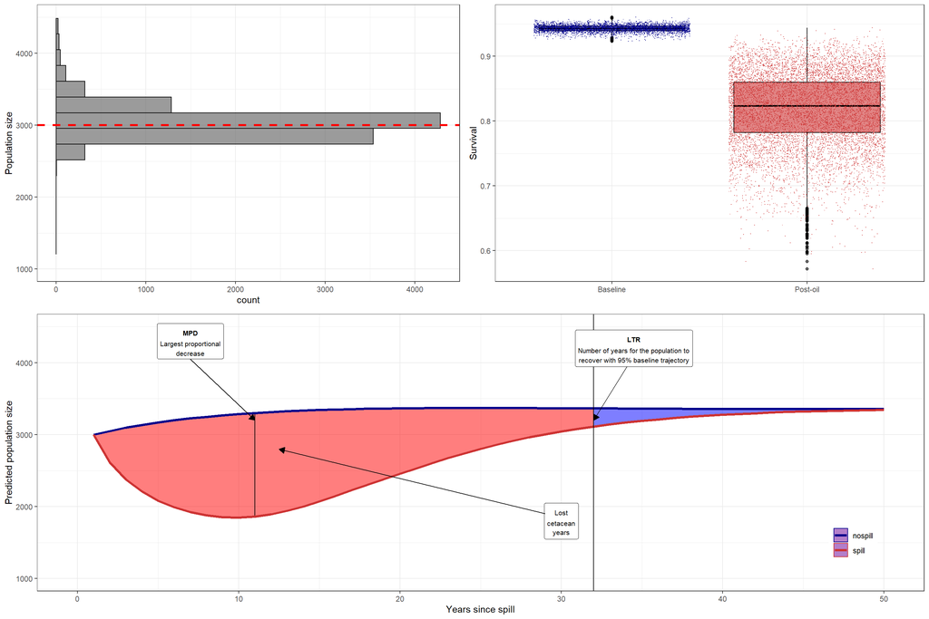

```r
layout_matrix <- matrix(c(1, 1, 2, 2, 4, 3, 3, 4), nrow = 2, byrow = TRUE)
grid.arrange(numberplot,baselsurv,bestplot1, layout_matrix = matrix(c(1,3,2,3), nrow = 2))
```

or simply the population trajectories, with added estimates from SECR population size, which corresponds to figure 4 in the manuscript

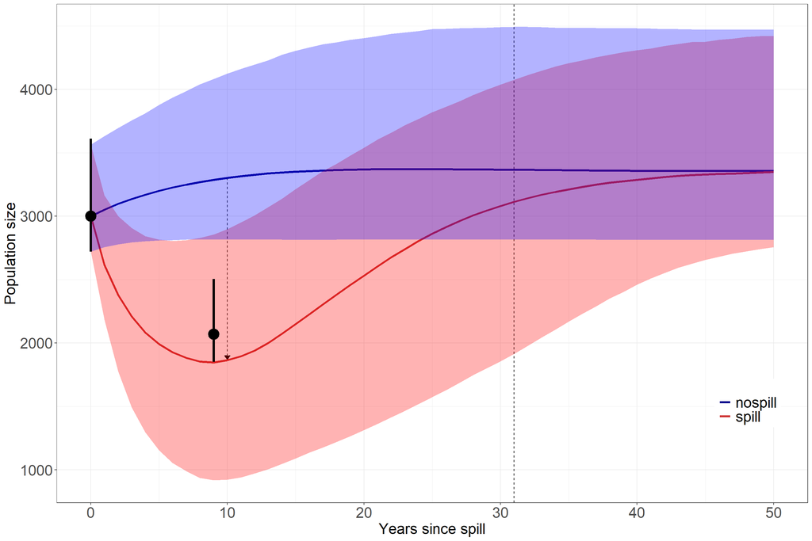

```r
bas2019<- read_csv("InOutBySp/Bottlenose_dolphin_BB/N_boot2019.csv")
N_boot <- read_csv("InOutBySp/Bottlenose_dolphin_BB/N_boot.csv")
dattat1<-N_boot%>%
summarise(Mean=mean(x), Max=max(x), Min=min(x), Median=median(x), Std=sd(x),quantile975=quantile(x,probs=0.975),quantile025=quantile(x,probs=0.025))

dattat<-bas2019%>%
summarise(Mean=mean(x), Max=max(x), Min=min(x), Median=median(x), Std=sd(x),quantile975=quantile(x,probs=0.975),quantile025=quantile(x,probs=0.025))


 ggplot() +
  #geom_ribbon(data = subset(data4,year<= YTR),aes(ymin = ymin,ymax=ymax,x=year), fill = "red", alpha = .4)+
  #geom_ribbon(data = subset(data4,year>= YTR),aes(ymin = ymin,ymax=ymax,x=year), fill = "blue", alpha = .4)+
annotate("segment",x=MPD-1,xend=MPD-1,yend=data4$y,y=data4$yend,colour="black",linetype = "dashed", arrow = arrow(type="closed", length = unit(0.1, "inches")))+
  geom_line(aes(x=data4$year-1,y=data4$population,color=data4$oil,lwd=2),size=1.4)+
  theme_bw()+
 #   annotate("segment", yend = 1000, y = 4500, x = YTR, xend = YTR,colour = "black", arrow = arrow(type="closed", length = unit(0.1, "inches")),linetype="dashed") +
  geom_vline(xintercept=YTR-1,linetype="dashed")+
  labs(colour="")+
  scale_color_manual(values=c("darkblue","brown3"))+
  ylab("Population size")+
  xlab("Years since spill")+
  #annotate("segment", xend=YTR, x= 34.5, y= 4100, yend= 3200, arrow = arrow(type="open", length = unit(0.1, "inches")))+
  #annotate('label',
        #   label = 'atop(atop("", bold("YTR")), atop("Number of years for the population to", "recover with 95% baseline trajectory"))',
       #    y = 4200, x = 34.5, parse = T)+
  #annotate('label',
   #        label = 'atop(atop("", "Lost"), atop("cetacean", "years"))',
    #       y = 1800, x = 30, parse = T)+
  #annotate("segment", xend=12.5, x=29, y= 1900, yend= 2800, arrow = arrow(type="open", length = unit(0.1, "inches"))) +
  #annotate('label',
   #        label = 'atop(atop("", bold("MPD")), atop("Largest proportional", "decrease"))',
    #       y = 4300, x = 7, parse = T)+
  #annotate("segment", xend=MPD, x= 7, y= 4050, yend= 2500, arrow = arrow(type="open", length = unit(0.1, "inches")))+
  theme(legend.position = c(0.92, 0.2))+xlim(0,50)+   geom_ribbon(data = subset(data4,oil=="spill"),aes(x=year-1,y=Median,ymin =quantile025,ymax=quantile975),fill="red", alpha = .3)+
  geom_ribbon(data = subset(data4,oil=="nospill"),aes(x=year-1,y=Median,ymin =quantile025,ymax=quantile975),fill="blue", alpha = .3)+
   #to change font size on labels and axis
  theme(axis.text.x = element_text(size = 20),
        axis.text.y = element_text(size = 20),
        axis.title.x = element_text(size = 20),
        axis.title.y = element_text(size = 20),
        legend.text=element_text(size=20)) +
  geom_pointrange(data=dattat, aes(x=9,
              y=Median,ymin=quantile025,ymax=quantile975),size=1.5) +
 geom_pointrange(data=dattat1, aes(x=0,
               y=Median,ymin=quantile025,ymax=quantile975),size=1.5)
```

The results paragraph in the paper is:

The mean initial population size was 3045 (95% credible intervals of 2720;3611) (figure 4, top left panel). The mean of the survival pre oil spill was 0.943 (95% credible intervals of 0.931;0.953) while the mean of the survival post oil spill was 0.818 (95% credible intervals of 0.695;0.909), leading to an average reduction in survival post-oil spill of 0.868 (95% credible intervals of 0.737;0.964). The average population trajectory under the presence of the oil spill and assuming the oil spill never happened are shown in Figure 4 (bottom panel). There were 28418 median LCY (95% percentile CI 6978-83760), the maximum proportional decrease was 44.1 % (95% percentile CI 15.5-72.7) and it took a median of 32 (95% percentile CI 18-56) years for 95 % recovery.

# Aknowledgments

We would like to thank Carolina Marques for the code and data wrangling that made this plot.